# Reproducible Research: Peer Assessment 1

Miriam Paz

15-10-2024

## Loading and preprocessing the data

```r
setwd("C:/Users/glori/Downloads") #If you need to change the directory, type the new one in this line
library(readr)
activity <- read_csv("activity.zip")
spec(activity)
summary(activity)
```

```
##      steps             date               interval
##  Min.   :  0.00   Min.   :2012-10-01   Min.   :   0.0
##  1st Qu.:  0.00   1st Qu.:2012-10-16   1st Qu.: 588.8
##  Median :  0.00   Median :2012-10-31   Median :1177.5
##  Mean   : 37.38   Mean   :2012-10-31   Mean   :1177.5
##  3rd Qu.: 12.00   3rd Qu.:2012-11-15   3rd Qu.:1766.2
##  Max.   :806.00   Max.   :2012-11-30   Max.   :2355.0
##  NA's   :2304
```

The dataset contains information about 3 variables: steps, date and interval.

### Histogram showing the total number of steps taken each day

First I calculated the total steps without missing values (NA), and I used the package “tidyverse”, which has functions that allows to group activity per day and calculates the total amount of steps.

```r
sum(activity$steps,na.rm=TRUE)
```

```
## [1] 570608
```

```r
library(tidyverse)
```

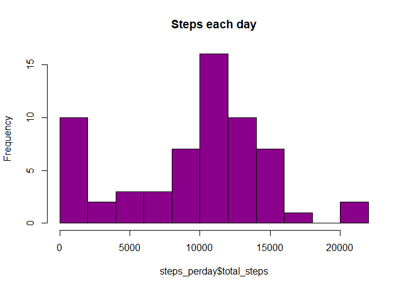

```r
steps_perday <- activity %>%
  group_by(date) %>%
  summarize(total_steps = sum(steps, na.rm = TRUE))

#Then I made a histogram using "hist()" showing the mean steps per day:

hist(steps_perday$total_steps,
     main="Steps each day",
     col= "darkmagenta",
     breaks = 10
)
```

## What is mean total number of steps taken per day?

To calculate the mean and median number of steps taken each day, I used the functions “mean()” and “median()” from the “steps_perday” data.

```r
mean(steps_perday$total_steps)
```

```
## [1] 9354.23
```

```r
median(steps_perday$total_steps)
```

```
## [1] 10395
```

The calculated mean is 9354.23 and the median is 10395.

## What is the average daily activity pattern?

First I created another dataframe on the mean steps per 5-minute interval called “steps_perinterval” and made a time series plot with this data by using the “plot()” function.

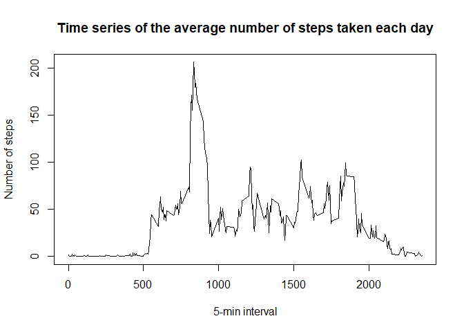

```r
steps_perinterval <- activity %>%
  group_by(interval) %>%
  summarize(mean_steps = mean(steps, na.rm = TRUE))

plot(steps_perinterval,
     xlab="5-min interval",
     ylab= "Number of steps",
     main= "Time series of the average number of steps taken each day",
     type = "l")
```

With this, a time series of the average number of steps taken each day is shown.

To calculate the 5-minute interval that contains the maximum number of steps, first I used the “max()”.

```r
max(steps_perinterval$mean_steps)
```

```
## [1] 206.1698
```

```r
steps_perinterval$interval[which.max(steps_perinterval$mean_steps)]
```

```
## [1] 835
```

The interval with the maximum number of steps is 835, with around 206 steps.

## Imputing missing values

First, I used the function “sum()” and “is.na()” to identify how many NA are there in our dataframe.

```r
sum(is.na(activity))
```

```
## [1] 2304
```

The total number of missing values (NA) in the dataset is 2304.

I used dplyr functions “left_join()”, “mutate()” and “select()” to fill-in the missing values (NA) in the dataset with the average of steps per interval.

```r
activity_imputedValues <- activity %>%
  left_join(steps_perinterval, by = "interval") %>%
  mutate(steps = case_when(is.na(steps) ~ mean_steps,
                           TRUE ~ steps)) %>%
  select(-mean_steps)

activity_imputedValues_stepsperday <- activity_imputedValues %>%
  group_by(date) %>%
  summarize(total_steps = sum(steps, na.rm = TRUE))
```

The new dataset created is called “activity_imputedValues_stepsperday”, which I used to make the histogram of the total number of steps taken each day after missing values are imputed.

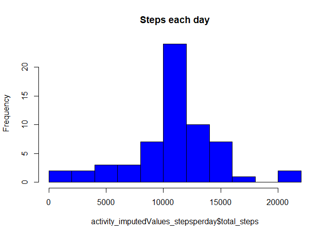

```r
hist(activity_imputedValues_stepsperday$total_steps,
     main="Steps each day",
     col= "blue",
     breaks = 10
)
```

```r
mean(activity_imputedValues_stepsperday$total_steps)
```

```
## [1] 10766.19
```

```r
median(activity_imputedValues_stepsperday$total_steps)
```

```
## [1] 10766.19
```

## Are there differences in activity patterns between weekdays and weekends?

For that, I used the dataset with filled-in values “activity_imputedValues”, and I used dplyr functions “mutate” to create a column that would write weekend if it’s “Saturday” and “Sunday” (“sábado” and “domingo”), or else call it weekday.

```r
activity_imputedValues_weekends_weekdays <- activity_imputedValues %>%
  mutate(is_weekend = case_when(weekdays(date) %in% c("sábado", "domingo")
                                ~ "weekend",
                           TRUE ~ "weekday"))
```

Then, I created a new factor variable with the 2 levels created above, “weekend” and “weekday”.

```r
activity_imputedValues_weekends_weekdays$is_weekend <- factor(activity_imputedValues_weekends_weekdays$is_weekend)
```

Later, I created 2 dataframes, one for the data on weekends “activity_imputedValues_weekendsonly” and the other for weekdays “activity_imputedValues_weekdays”, by using the “filter()” function.

```r
activity_imputedValues_weekendsonly <- activity_imputedValues_weekends_weekdays %>%
  filter(is_weekend == "weekend")

activity_imputedValues_weekdays <- activity_imputedValues_weekends_weekdays %>%
  filter(is_weekend == "weekday")
```

And I created two dataframes with the average number of steps per weekday and weekend days separately, compared to the 5-minute interval.

```r
steps_perinterval_weekends <- activity_imputedValues_weekendsonly %>%
  group_by(interval) %>%
  summarize(mean_steps = mean(steps, na.rm = TRUE))

steps_perinterval_weekdays <- activity_imputedValues_weekdays %>%
  group_by(interval) %>%
  summarize(mean_steps = mean(steps, na.rm = TRUE))
```

Here I used the function “par()” to create a multi-panel figure of 2x1 with the time-series of both dataframes, to compare the average steps per weekend versus weekdays.

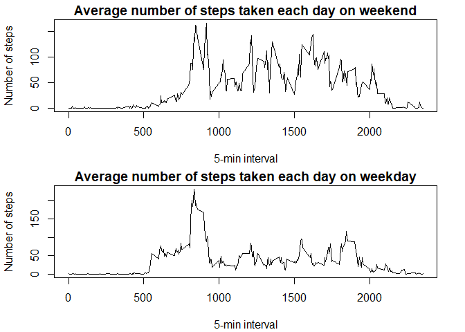

```r
par(mfrow = c(2,1), mar = c(4.1, 4.1, 1.5, 2.1))
plot(steps_perinterval_weekends,
     xlab="5-min interval",
     ylab= "Number of steps",
     main= "Average number of steps taken each day on weekend",
     type = "l")
plot(steps_perinterval_weekdays,
     xlab="5-min interval",
     ylab= "Number of steps",
     main= "Average number of steps taken each day on weekday",
     type = "l")
```